# Final Project - Seacoast’s Wasted Votes

Daniel Pontoh

May 3, 2016

##### Introduction

For my DATA210 Final Project I wanted to look @ the “wasted votes” and “efficiency gap” metrics in New Hampshire’s Seacoast region for the State Representative General Elections in each legislative district.

The political metric ‘Wasted Votes’ is the number of surplus votes for a candidate in an election that exceeds the total number of votes needed to win (which is 1 + half the total votes). The other metric ‘efficiency gap’ is the number of wasted votes divided by the total number of votes cast as a percentage.

To do this project, I needed the election data for the target districts which I obtained from New Hampshire Public Radio’s State of Democracy stats site “nh.electionstats.com”. After putting all the data into a spreadsheet, I worked in R to add a few more data columns of calculations and data points, munge the data table, and to make the visualizations.

IMPORTANT: Please read the disclaimer at the very bottom of the page. This exploration is far from perfect.

```r
library(dplyr)
library(readr)
library(ggplot2)
library(tidyr)
library(scales)
```

# Calculations

```r
#Data is from http://nh.electionstats.com/elections/view/48797/ to /48858

#Put csv file into a dataframe
results <- read_csv("data/electionresults.csv")

#Make better column names
colnames(results) <- c("id",
                       "numb_dem_votes",
                       "numb_rep_votes",
                       "numb_ind_Votes",
                       "numb_tot_votes",
                       "seat_make_up",
                       "contested",
                       "numb_tot_seates",
                       "numb_dem_cand",
                       "numb_rep_cand",
                       "numb_ind_cand")




#To get the number of wasted votes for each district,
#we need to see how many votes over the number of votes
#needed to win the district there werefor each party.

#(Party) Waste Votes =(total # of votes for a party)-(total number of votes cast/2)

#Make column of wasted votes for democratic party
results$numb_dem_waste <- results$numb_dem_votes - (results$numb_tot_votes/2)

#Make column of wasted votes for republican party
results$numb_rep_waste <- results$numb_rep_votes - (results$numb_tot_votes/2)


#The Efficiency gap is the percentage wasted votes
#divided by the total number of votes
#times 100.
#Efficiency Gap = (party's waste votes / total votes) * 100

#Get rid of negative numbers
results <- mutate(results, numb_dem_waste2 = ifelse(numb_dem_waste < 0, 0, numb_dem_waste))

results <- mutate(results, numb_rep_waste2 = ifelse(numb_rep_waste < 0, 0, numb_rep_waste))

#Efficiency gap for democratic party
results$dem_eff_gap <- 100 * (results$numb_dem_waste2 / results$numb_tot_votes)

results$dem_eff_gap2 <- 100 * (results$numb_dem_waste / results$numb_tot_votes)


#Efficiency gap for republican party
results$rep_eff_gap <- 100 * (results$numb_rep_waste2 / results$numb_tot_votes)

results$rep_eff_gap2 <- 100 * (results$numb_rep_waste / results$numb_tot_votes)



#The Surplus is how much more votes
#one party had than the other.
#Surplus = Party 1's total votes - Party 2's total votes

#Surplus votes for democratic party
results$numb_dem_surplus <- (results$numb_dem_votes - results$numb_rep_votes)

#Surplus votes for republican party
results$numb_rep_surplus <- (results$numb_rep_votes - results$numb_dem_votes)

#Make a dataframe of just the contested elections
allcontestedracedata <- results[results$contested == TRUE,]
str(results)
```

```
## Classes 'tbl_df', 'tbl' and 'data.frame':    62 obs. of  21 variables:
##  $ id              : chr  "Rockingham No. 1" "Rockingham No. 2" "Rockingham No. 3" "Rockingham No. 4" ...
##  $ numb_dem_votes  : num  701 5900 0 4426 19323 ...
##  $ numb_rep_votes  : num  965 8973 5993 18873 32879 ...
##  $ numb_ind_Votes  : num  0 0 126 13 50 0 1370 51 6 35 ...
##  $ numb_tot_votes  : int  1666 14873 6119 23312 52252 40972 19339 65333 4342 1253 ...
##  $ seat_make_up    : chr  "(1/1)" "(3/3)" "(3/3)" "(5/5)" ...
##  $ contested       : logi  TRUE TRUE FALSE TRUE TRUE TRUE ...
##  $ numb_tot_seates : int  1 1 3 5 7 10 4 9 2 1 ...
##  $ numb_dem_cand   : int  1 3 0 2 7 4 3 7 2 0 ...
##  $ numb_rep_cand   : int  1 3 3 5 7 10 4 9 2 1 ...
##  $ numb_ind_cand   : int  0 0 0 0 0 0 1 0 0 0 ...
##  $ numb_dem_waste  : num  -132 -1536 -3060 -7230 -6803 ...
##  $ numb_rep_waste  : num  132 1536 2934 7217 6753 ...
##  $ numb_dem_waste2 : num  0 0 0 0 0 0 0 0 0 0 ...
##  $ numb_rep_waste2 : num  132 1536 2934 7217 6753 ...
##  $ dem_eff_gap     : num  0 0 0 0 0 0 0 0 0 0 ...
##  $ dem_eff_gap2    : num  -7.92 -10.33 -50 -31.01 -13.02 ...
##  $ rep_eff_gap     : num  7.92 10.33 47.94 30.96 12.92 ...
##  $ rep_eff_gap2    : num  7.92 10.33 47.94 30.96 12.92 ...
##  $ numb_dem_surplus: num  -264 -3073 -5993 -14447 -13556 ...
##  $ numb_rep_surplus: num  264 3073 5993 14447 13556 ...
```

```r
#I saved the new dataset into a .csv for sharing
write_csv(results, path = "data/nhelectiondata.csv")
```

# Datamunging

Code to clean up data.

```r
elec <- read_csv("data/nhelectiondata.csv")

#Select columns of interest
waste <- select(elec, id, numb_dem_waste, numb_rep_waste, contested)

waste_long <- gather(waste, party, count, -id, -contested)

waste_long <- filter(waste_long, count > 0)

waste_long <- mutate(waste_long, count = ifelse(party == "numb_dem_waste", -count, count))

waste_long <- mutate(waste_long, party = ifelse(party == "numb_dem_waste", "D", "R"))

waste_long <- mutate(waste_long,
                     count = as.integer(count))

waste_long <- arrange(waste_long, count)

waste_long <- mutate(waste_long,
                     id=factor(id,
                               levels=waste_long$id))

waste_long <- mutate(waste_long,
                     id=factor(id,
                               levels=rev(waste_long$id)))

waste_long <- mutate(waste_long,
                     just = ifelse(party == "D", 0, 1))

waste_long <- mutate(waste_long,
                     lab=ifelse(sign(count)<0,
                                sprintf("(%s) %s", comma(abs(count)), id),
                                sprintf("%s (%s)", id, comma(abs(count)))))
```

# Wasted Votes

For the barplots below, blue indicates democratic votes and red indicates republican votes.

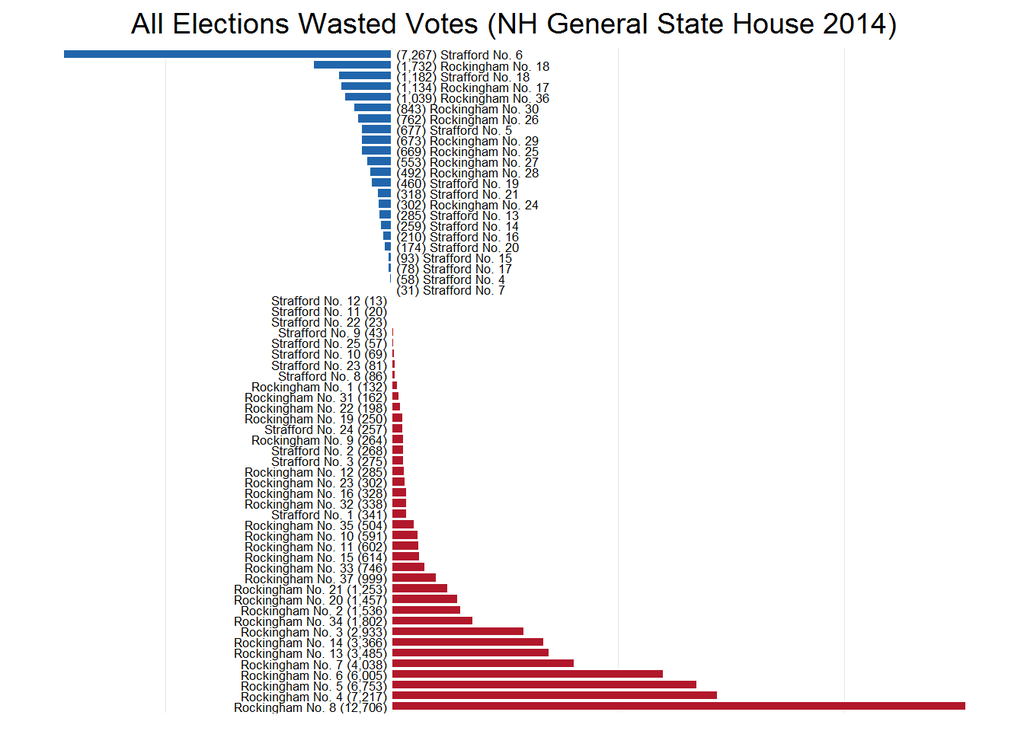

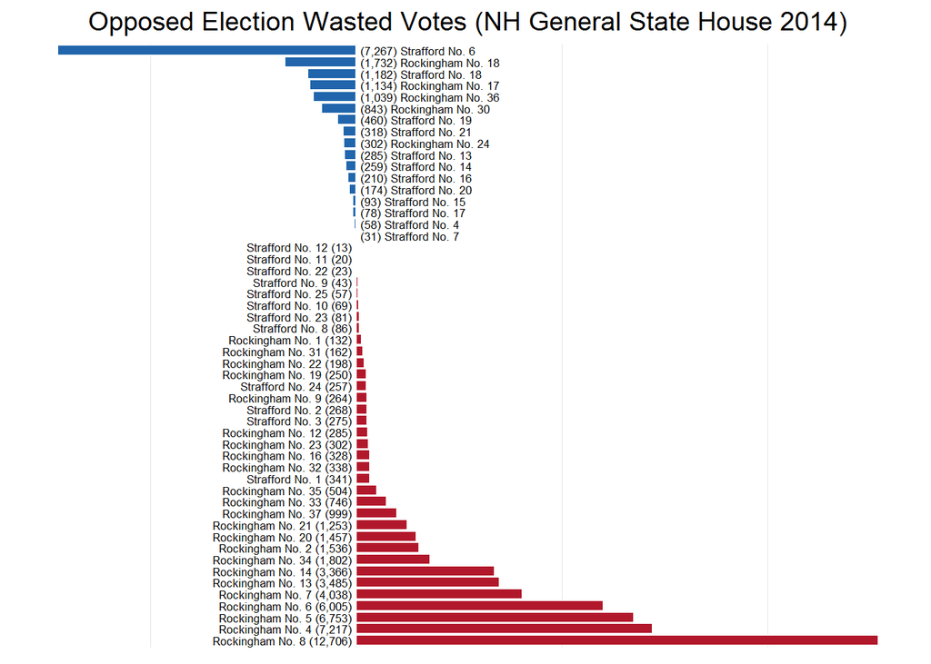

# Efficiency Gap (makes data relative)

50% +/- 1-2% indicates an unopposed election.

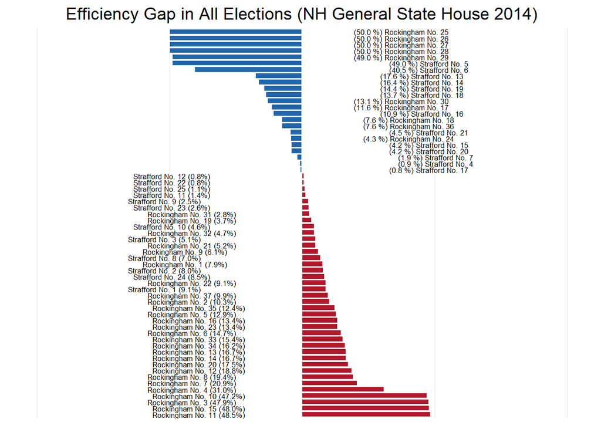

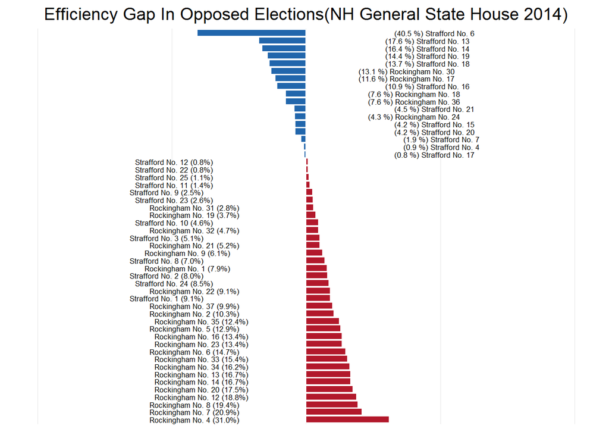

# More Calculations + df’s

```r
republicandat <- c("R",
                   as.integer(sum(results$numb_rep_waste[sign(results$numb_rep_waste) >= 1])),
                   as.integer(sum(allcontestedracedata$numb_rep_waste[sign(allcontestedracedata$numb_rep_waste) >= 1])),
                   as.integer((sum(results$numb_rep_waste[sign(results$numb_rep_waste) >=1])) - sum(allcontestedracedata$numb_rep_waste[sign(allcontestedracedata$numb_rep_waste) >= 1])),
                   length(results$id[sign(results$numb_rep_waste) >= 1]),
                   length(allcontestedracedata$id[sign(allcontestedracedata$numb_rep_waste) >= 1]),
                   length(results$id[sign(results$numb_rep_waste) >= 1]) - length(allcontestedracedata$id[sign(allcontestedracedata$numb_rep_waste) >= 1]))

democratdat <- c("D",
                 as.integer(sum(results$numb_dem_waste[sign(results$numb_dem_waste) >=1])),
                 as.integer(sum(allcontestedracedata$numb_dem_waste[sign(allcontestedracedata$numb_dem_waste) >= 1])),
                 as.integer((sum(results$numb_dem_waste[sign(results$numb_dem_waste) >=1])) - sum(allcontestedracedata$numb_dem_waste[sign(allcontestedracedata$numb_dem_waste) >= 1])),
                 length(results$id[sign(results$numb_dem_waste) >= 1]),
                 length(allcontestedracedata$id[sign(allcontestedracedata$numb_dem_waste) >= 1]),
                 length(results$id[sign(results$numb_dem_waste) >= 1]) - length(allcontestedracedata$id[sign(allcontestedracedata$numb_dem_waste) >= 1]))

republicandat <- t(republicandat)
democratdat <- t(democratdat)

bigpic <- rbind(republicandat, democratdat)

colnames(bigpic) <- c("party", "total_waste", "total_waste_contested", "total_waste_diff", "all_districts_won", "only_districts_won", "uncontested_districts")

bigpic <- data.frame(bigpic)
```

# Democrat vs. Republican

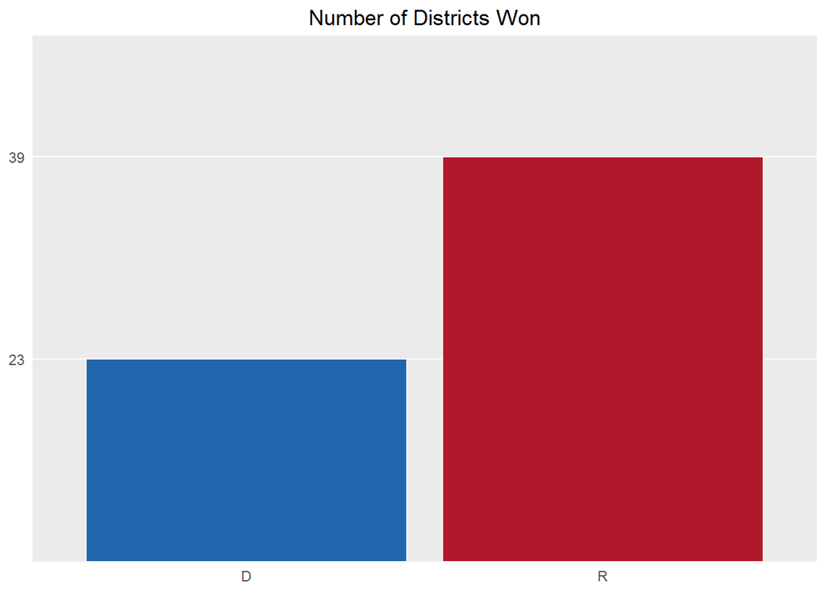

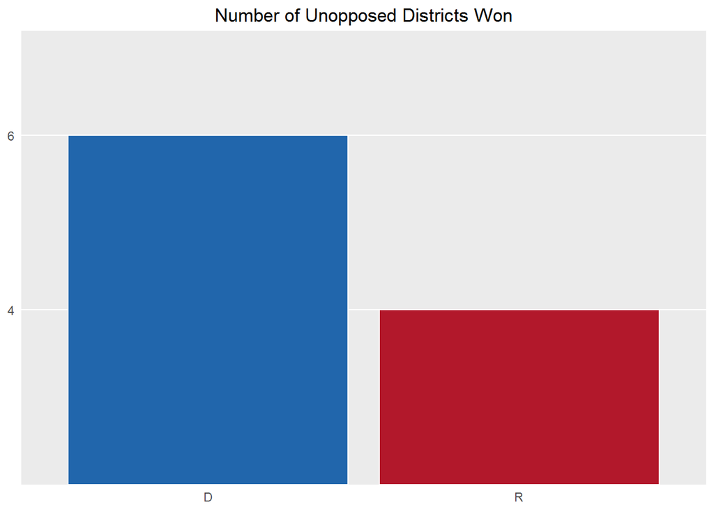

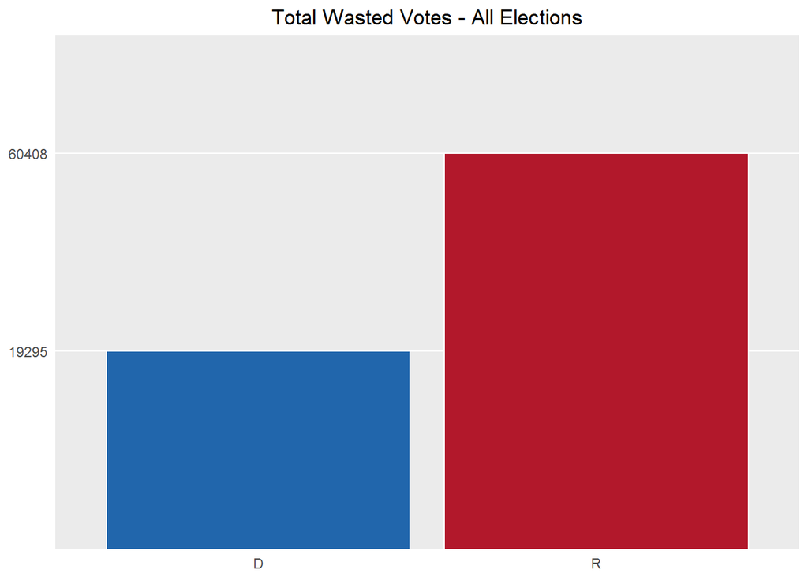

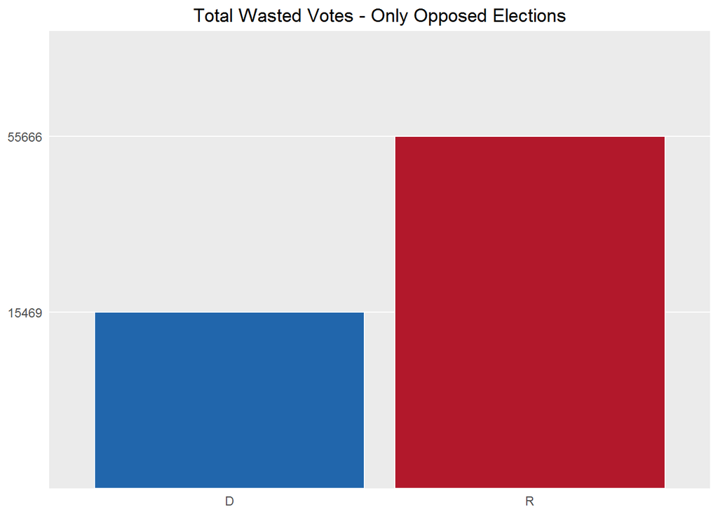

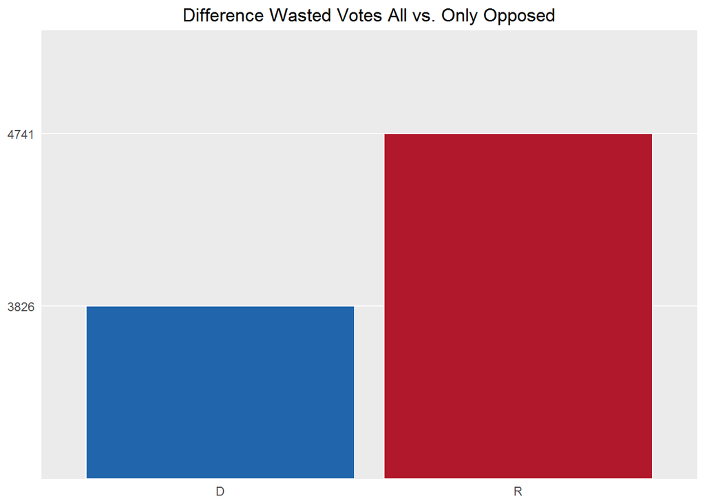

# The next two maps look at the concentration of voters and seats in each district.

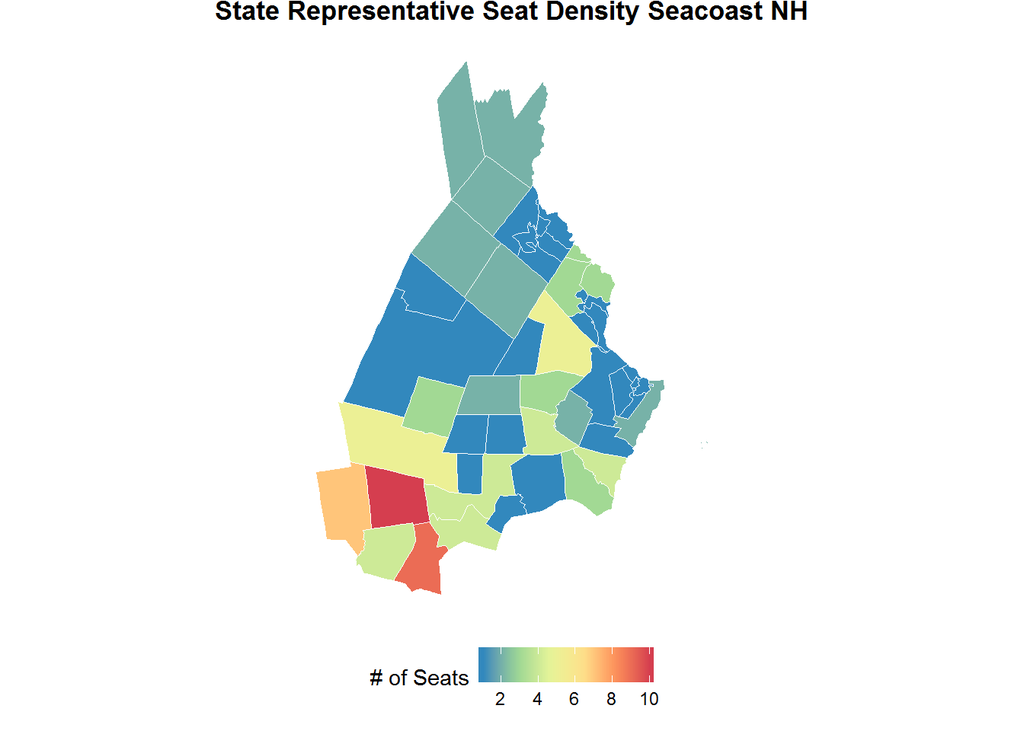

```r
###########################################
######### Generating the maps #############
#########################################

gg <- ggplot() +
  geom_polygon(data = final_plot,
               aes(x = long, y = lat, group = group, fill = numb_tot_seates),
               color = "white", size = 0.25) +
  coord_map() +
  scale_fill_distiller(name = "# of Seats", palette = "Spectral", breaks = pretty_breaks(n = 5)) +
  theme_nothing(legend = TRUE) +
  labs(title = "State Representative Seat Density Seacoast NH") +
  theme(legend.position = "bottom") +
  theme(plot.title = element_text(face = "bold", hjust= 0.5))
gg
```

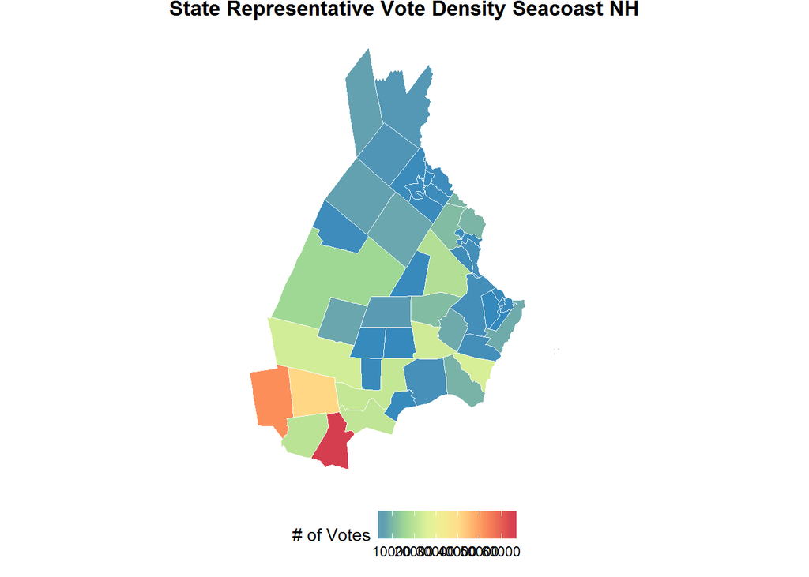

```r
gg <- ggplot() +
  geom_polygon(data = final_plot,
               aes(x = long, y = lat, group = group, fill = numb_tot_votes),
               color = "white", size = 0.25) +
  coord_map() +
  scale_fill_distiller(name = "# of Votes", palette = "Spectral", breaks = pretty_breaks(n = 5)) +
  theme_nothing(legend = TRUE) +
  labs(title = "State Representative Vote Density Seacoast NH") +
  theme(legend.position = "bottom") +
  theme(plot.title = element_text(face = "bold", hjust= 0.5)) +
  scale_size_area(max_size = 100)
gg
```

# This map shows where the greatest efficiency gaps are.

-The red/orange indicates a positive republican efficiency gap. -The white/blue indicates a positive democratic efficiency gap.

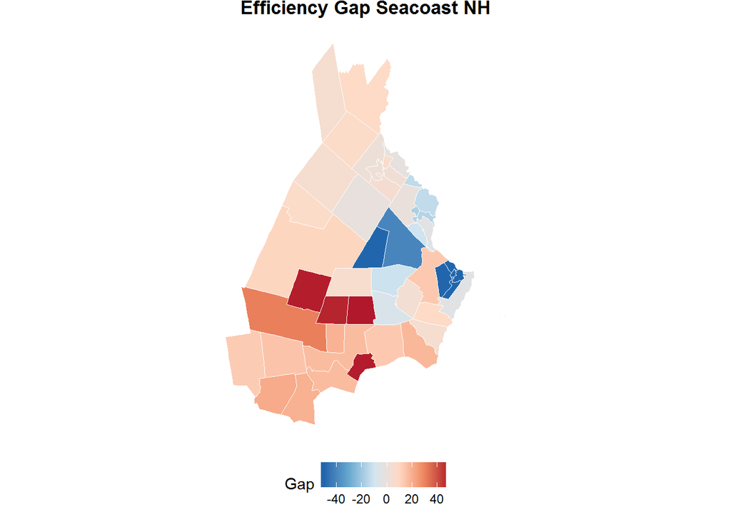

```r
gg <- ggplot() +
  geom_polygon(data = final_plot,
               aes(x = long, y = lat, group = group, fill = rep_eff_gap2),
               color = "white", size = 0.25) +
  coord_map() +
  scale_fill_distiller(name = "Gap", palette = "RdBu", breaks = pretty_breaks(n = 5)) +
  theme_nothing(legend = TRUE) +
  labs(title = "Efficiency Gap Seacoast NH") +
  theme(legend.position = "bottom") +
  theme(plot.title = element_text(face = "bold", hjust= 0.5))
gg
```

##### Disclaimers

- I have no credentials that qualify me to be a political scientist/analyst. I just did this because the data was public and I thought it would be cool to play with.
- The metrics “wasted votes” and “efficiency gap” are typically used for head to head elections. So situations where a voter can only vote for one person. New Hampshire’s State Representative General Elections can involve anywhere from one to ten seats up for grabs for a particular district so voters will vote for multiple candidates in an election.
- After thorough consideration, I don’t know if there is a best way to get the political metrics other than trying multiple approaches.
- My approach takes the total number of votes for each party for a district and pits them against each other. It does not take into consideration the number of candidates running or how many candidates of each party are running. This becomes a problem when you have unbalanced contests such as Derry which had 10 seats up for grabs but had 10 Republicans run and 4 Democrats run. Another problem would be a case like Strafford 17 where there were 3 seats up for grabs but 1 republican won and 2 democrats won.

##### References

1. Inspiration for project - http://nhpr.org/post/new-hampshire-shifts-swing-state-why-do-legislative-lines-still-favor-republicans
2. Data came from - http://www.nh.electionstats.com
3. Wasted vote and efficiency gap definitions - https://newrepublic.com/article/118534/gerrymandering-efficiency-gap-better-way-measure-gerrymandering